# ENG Верификация авторства поэмы «Ишк̣-нāме»

We turn to modern multivariate stylometry to see if computational models would provide an additional evidence for disputed authorship. We will rely on the frequencies of the most frequent words as reliable features of stylistic identity, as it was demonstrated an abundance of times (see e.g. (Evert et al. 2017) ). The use of so-called “function words” from the top of the word frequency list often significantly varies among individuals which allows to distinguish their mostly unconscious writing habits, or stylistic signatures ((Kestemont 2014)). However, in the case of attributing poetic texts the main problem often encountered is the insufficient text size: robust lexical patterns do not have space to express themselves in short texts (Eder 2017). Recent research in versification increases reliability of attribution by adding formal features of verse - like rhythm patterns and rhyme composition (Plecháč 2021). However, the lexical-based attribution even in short poetry samples still remains relevant. Given availability of relatively large samples (~5000 words) in our scenario, we proceed with the simplest setup possible. In all experiments we rely on `stylo` library for R software (Eder, Rybicki, and Kestemont 2016), wrapping its functions in custom-made experimental scenarios.

The only plausible candidate for the authorship of “Book of Love” in our corpus of poetic texts is Sanayi. This means that the main goal of stylometry experiments is *verification* of authorship, instead of *attribution*. Attribution setup usually has closed set of candidates to which an unknown text is being attributed. In verification, which is usually considered more general task, a goal is to verify if a text could have been written by the only “suspect” author (Halvani, Winter, and Graner 2019). We use other poets as a set of “impostors,” a background against which stylistic features of Sanayi and “Book of Love” would be matched. Following table provides text size summaries (in number of tokens / words).

| title | n |
| --- | --- |
| Ibn Imad Shirazi_Raudat al-muhibbin_1392_hazadzh | 7607 |
| Iraqi_Diwan | 60836 |
| Iraqi_Ushshaqname_hafif | 10640 |
| Marageyi_Mantiq al-ushshaq_1306_hazadzh | 6268 |
| Sanayi_Hadiqat_hafif | 5861 |
| Sanayi_Ishqname_hafif | 6383 |
| Sanayi_Sayr al-ibad_hafif | 8466 |
| Ubayd Zakkani_Ushshaqname_1350_hazadzh | 7943 |

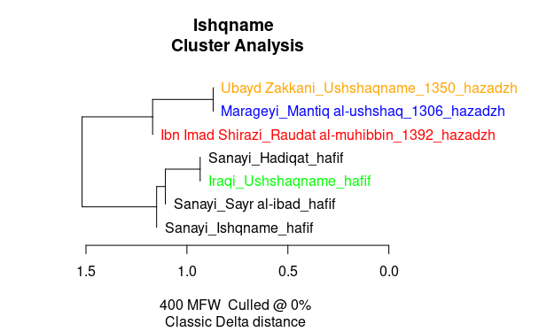

To minimize future structural bias that is introduced with meter, we might want to remove features (words) that are mostly associated with the metrical groups. We do it by correlating features of texts with their metrical classes.

```
##          Eta2 P-value
## امیدواری 0.98   2e-05
## بترس     0.98   2e-05
## برید     0.98   2e-05
## پرداز    0.98   2e-05
## ریشم     0.98   2e-05
## زارم     0.98   2e-05
## سرمایه   0.98   2e-05
## غمناک    0.98   2e-05
## فتنه     0.98   2e-05
## کارگر    0.98   2e-05
```

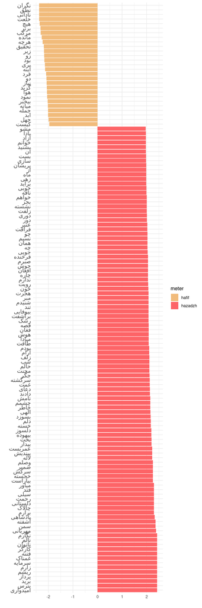

In following experiments these words are excluded to counter the natural similarity of same-meter texts to each other. This would not neutralize the global effect of poetic meter on natural language, but at least some control over these features is important.

For a start, we want to test our experimental method in “ground truth” cases where there is no doubt in true authorship of a text. To do this, we take Iraqi and Sanayi, since they are the only authors in our corpus that have two different texts. We want to test how random samples of 5000 words are recognized as samples “of the same author.” We use a method known as “general impostors” (Kestemont et al. 2016): it is an iterative attribution of a fragment X to all other authors in the corpus (including the one who actually wrote X). The confidence in attribution is expressed as a proportion of cases in which the fragment was the nearest neighbor to author A, as a results of N iterations. Here we run each of 20 indepdendent sample pools of 5000 words per each text 1000 times across all texts in corpus (excluding the “Book of Love”).

Results for Iraqi’s Diwan.

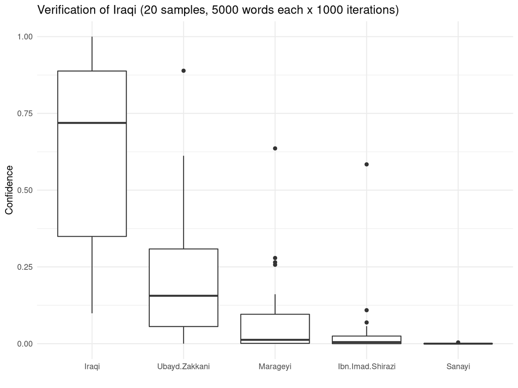

Results for Sanayi (in each sampling round the Sanayi poem for verification was chosen randomly)

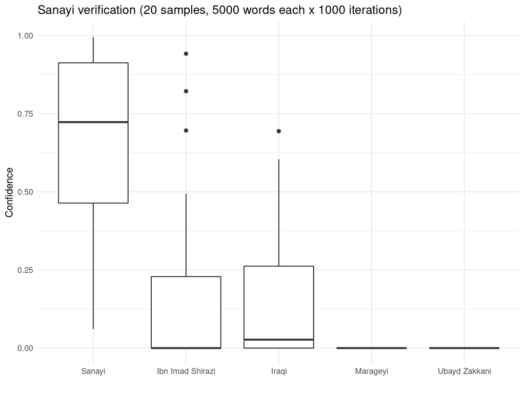

The current setup of the corpus and sample size, as it is evident, is far from being certain about true authorship. However, the tendency to verify a text against it’s true author is there. We certainly pick upon *some* authorial signal.

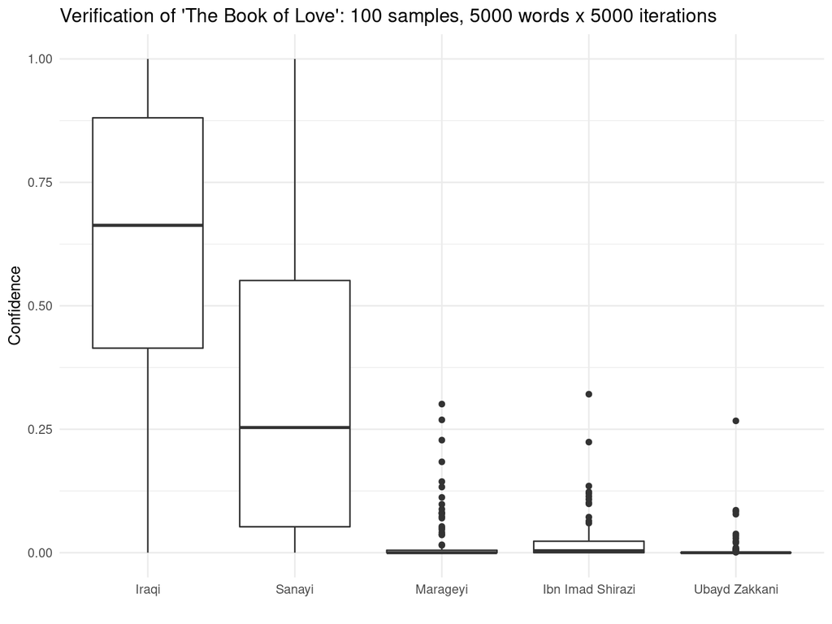

Our primary (and only) candidate for the authorship of “Book of Love” is Sanayi and he even loses the competition to Iraqi, who is not even considered a plausible candidate. It is important to note, that the method that is used here will always assign a nearest neighbor to a text without any estimation how “true” this assignment is. The high uncertainty and dispersion of our results could be seen as indicative of the lack of a true author in the corpus. Then, the “similarity” of “Book of Love” to Iraqi and Sanayi might be driven by other factors, like meter or theme (or both). In any case, the results show that probability of Sanayi being an author of “Book of Love” is small - this does not mean, it is non-existent. As we shown, our certainty in this experimental scenario is limited.

We can try to visualize the processes behind verification experiments. To do this, we calculate distances between two random samples taken from “true” Sanayi, using different most frequent word cutoffs for analysis. Resulting average distances then are compared to sets of distances between “true” Sanayi and others authors in the corpus. This gives us an an estimation of how same-author samples from uncontested Sanayi behave compared to other-author samples. Using these results as a “map” of same vs. other author similarity, we add distances from samples from “Book of Love” to samples from Sanayi. We can now see how the contested poem behaves: as Sanayi text (the curve is close to curve of Sanayi vs. Sanayi distances), or text plausibly written by someone else (the curve is close to Sanayi vs. others distances)

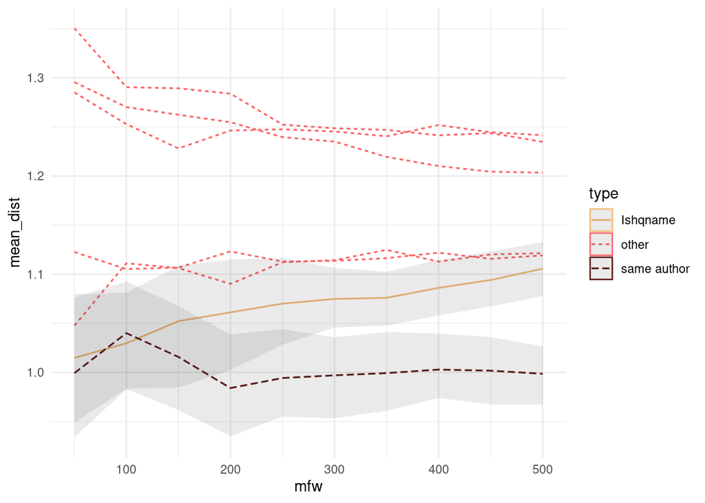

The lines on a plot show average distances, grey zone is 95% percentile interval of the distance distribution. 100 distance calculations were made in each MFW cutoff. Red lines are the distances of “other authors” to Sanayi, while the golden line shows distances between “Book of Love” and Sanayi. The golden line quickly leaves the space of Sanayi plausibility and approaches distances of “others” (Iraqi and Shirazi).

Burrows, John. 2002. “‘Delta’: A Measure of Stylistic Difference and a Guide to Likely Authorship.” *Literary and Linguistic Computing* 17 (3): 267–87. https://doi.org/10.1093/llc/17.3.267.

Eder, Maciej. 2017. “Short Samples in Authorship Attribution: A New Approach.” In *Digital Humanities 2017: Conference Abstracts*, 221–24. Montreal: McGill University. https://dh2017.adho.org/abstracts/341/341.pdf.

Eder, Maciej, Jan Rybicki, and Mike Kestemont. 2016. “Stylometry with R: A Package for Computational Text Analysis.” *R Journal* 8 (1): 107–21. https://journal.r-project.org/archive/2016/RJ-2016-007/index.html.

Evert, Stefan, Thomas Proisl, Fotis Jannidis, Isabella Reger, Steffen Pielström, Christof Schöch, and Thorsten Vitt. 2017. “Understanding and Explaining Delta Measures for Authorship Attribution.” *Digital Scholarship in the Humanities* 32 (suppl_2): ii4–16. https://doi.org/10.1093/llc/fqx023.

Halvani, Oren, Christian Winter, and Lukas Graner. 2019. “Assessing the Applicability of Authorship Verification Methods.” *arXiv:1906.10551 [Cs, Stat]*, June. https://doi.org/10.1145/3339252.3340508.

Kestemont, Mike. 2014. “Function Words in Authorship Attribution. From Black Magic to Theory?” In *Proceedings of the 3rd Workshop on Computational Linguistics for Literature (CLFL)*, 59–66. Gothenburg, Sweden: Association for Computational Linguistics. https://doi.org/10.3115/v1/W14-0908.

Kestemont, Mike, Justin Stover, Moshe Koppel, Folgert Karsdorp, and Walter Daelemans. 2016. “Authenticating the Writings of Julius Caesar.” *Expert Systems with Applications* 63: 86–96. https://doi.org/https://doi.org/10.1016/j.eswa.2016.06.029.

Plecháč, Petr. 2021. *Versification and Authorship Attribution*. Charles University in Prague, Karolinum Press.